# Supplementary Note 1: TransDecoder releases, 2012-2026

This notebook supports Supplementary Note 1 of the supplement (`../manuscript/supplement.tex`): the table of method changes in key releases (Table S10, `tab:releases`), the benchmark of key releases (Table S11, `tab:history`) and Fig. S3 (`fig:history`). Provenance: E23 (release history and runs of the old releases) and E25 (final v7 release runs).

Data:

- `data/benchmark/history/history_scores.tsv`: per-organism scores of r2012-08-07, v2.0, v4.1.0, v5.0.0 and v5.7.1 on the 20 stranded benchmark inputs with negatives (E23).
- `data/benchmark/final_v7/negatives_scores.tsv`: the same inputs scored for the v7 release (`pytd_v7`: PyTD main 3a793ff, release defaults, q 0.05; Perl devel 41fc5ee gives identical predictions) and for the development run with the fixed short-ORF test (`cliff_c200`) (E25).

Earlier versions of the table and figure used two development runs for v7 (`pytd_release`, the fixed short-ORF test, and `pytd_decoy_q0.05`, the q-value test from development code). Here the q-value row is the final release run. The fixed short-ORF test row is kept as a development run; `cliff_c200` in `negatives_scores.tsv` has the same counts as `pytd_release` in `history_scores.tsv` for all 20 inputs (checked below).

```r
hist <- read_tab("benchmark", "history", "history_scores.tsv")
neg <- read_tab("benchmark", "final_v7", "negatives_scores.tsv")

RELEASES <- tribble(
  ~label,         ~src,   ~row,                                    ~axis,
  "r2012",        "hist", "r2012-08-07",                           "r2012 (SourceForge)",
  "v2.0",         "hist", "v2.0",                                  "v2.0 (2015)",
  "v4.1.0",       "hist", "v4.1.0",                                "v4.1.0 (2017)",
  "v5.0.0",       "hist", "v5.0.0",                                "v5.0.0 (2017)",
  "v5.7.1",       "hist", "v5.7.1 (= v6.0.0)",                     "v5.7.1 (2023)",
  "cliff_c200",   "neg",  "v7 development, fixed short-ORF test",  "v7 dev., short-ORF test",
  "pytd_v7",      "neg",  "v7 (release), q 0.05",                  "v7 release, q 0.05"
)
VARIANTS <- c(complete.wRand = "Complete + random", fragments.wRand = "Fragments + random",
              complete.wLnc = "Complete + lncRNA", fragments.wLnc = "Fragments + lncRNA")

scores <- bind_rows(
  hist %>% filter(label %in% RELEASES$label[RELEASES$src == "hist"]),
  neg %>% filter(label %in% RELEASES$label[RELEASES$src == "neg"])
) %>% filter(variant %in% names(VARIANTS)) %>%
  # recompute rates from counts: the TSV columns are rounded to 4 decimals, and the median of two
  # rounded values can round differently at 3 decimals
  mutate(sens_stop = tp_stop / n_truth, sens_exact = tp_exact / n_truth, neg_rate = neg_with_pred / n_neg)

# same 20 inputs for every release
stopifnot(all(count(scores, label)$n == 20))

med <- scores %>%
  group_by(label, variant) %>%
  summarise(n_org = n(), sens_stop = median(sens_stop), sens_exact = median(sens_exact),
            neg_pct = 100 * median(neg_rate), .groups = "drop") %>%
  mutate(release = factor(RELEASES$row[match(label, RELEASES$label)], levels = RELEASES$row),
         variant = factor(variant, levels = names(VARIANTS)))
m <- function(lab, var, col) med[[col]][med$label == lab & med$variant == var]

# development fixed short-ORF test: identical counts in both tables
same_dev <- neg %>% filter(label == "cliff_c200") %>%
  inner_join(hist %>% filter(label == "pytd_release"), by = c("org", "variant")) %>%
  summarise(n = n(), diff = sum(abs(tp_stop.x - tp_stop.y) + abs(tp_exact.x - tp_exact.y) +
                                  abs(n_pred.x - n_pred.y) + abs(neg_with_pred.x - neg_with_pred.y)))
```

`cliff_c200` (E25) against `pytd_release` (E23): 20 inputs, summed absolute difference in TP stop, TP exact, predictions and negatives with a prediction: 0.

## Method changes in key releases

Table S10 (`tab:releases`) is a reading of the code and change log of each release (`data/benchmark/history/VERSIONS.md`, E23). It has no computed values. The release dates in the table:

```r
tribble(
  ~Release, ~Date, ~Source,
  "Trinity utility", "2011-2012", "Trinity Release.Notes",
  "r2012-08-07", "2012-08", "SourceForge archive",
  "v2.0", "2015-01 (tag 2015-01-26)", "git tag",
  "v4.1.0", "2017-08 (tag 2017-08-17)", "git tag",
  "v5.0.0", "2017-08 (tag 2017-08-26)", "git tag",
  "v5.4-v6.0.0", "2018-2026 (v5.4.0 2018-10-17; v6.0.0 2026-03-20)", "git tags",
  "v7 (this study)", "2026", "PyTD main 3a793ff, Perl devel 41fc5ee (E25)"
) %>% kable()
```

| Release | Date | Source |
| --- | --- | --- |
| Trinity utility | 2011-2012 | Trinity Release.Notes |
| r2012-08-07 | 2012-08 | SourceForge archive |
| v2.0 | 2015-01 (tag 2015-01-26) | git tag |
| v4.1.0 | 2017-08 (tag 2017-08-17) | git tag |
| v5.0.0 | 2017-08 (tag 2017-08-26) | git tag |
| v5.4-v6.0.0 | 2018-2026 (v5.4.0 2018-10-17; v6.0.0 2026-03-20) | git tags |
| v7 (this study) | 2026 | PyTD main 3a793ff, Perl devel 41fc5ee (E25) |

v6.0.0 gives the same predictions as v5.7.1 (VERSIONS.md section 4: phase scripts identical apart from paths and `--version`; identical smoke predictions), so v5.7.1 represents it below.

## Key releases on the benchmark

Medians over organisms (8 organisms with random negatives; human and mouse with lncRNA negatives) of stop-level sensitivity, exact-CDS sensitivity and the percentage of negative sequences with a prediction. Each release ran with its own defaults, `-S`, and a genetic code given only for *T. thermophila*; r2012 3’-partial ORFs were trimmed to the transcript before scoring (E23). v7 rows: E25.

```r
tab <- med %>%
  mutate(cell = sprintf("%s / %s / %s", f3(sens_stop), f3(sens_exact), f1(neg_pct))) %>%
  select(release, variant, cell) %>%
  pivot_wider(names_from = variant, values_from = cell) %>%
  arrange(release) %>%
  select(Release = release, all_of(names(VARIANTS)))
names(tab)[-1] <- VARIANTS[names(tab)[-1]]
kable(tab)
```

| Release | Complete + random | Fragments + random | Complete + lncRNA | Fragments + lncRNA |
| --- | --- | --- | --- | --- |
| r2012-08-07 | 0.935 / 0.666 / 0.1 | 0.759 / 0.620 / 0.0 | 0.965 / 0.618 / 16.2 | 0.781 / 0.633 / 15.7 |
| v2.0 | 0.935 / 0.667 / 0.1 | 0.764 / 0.623 / 0.0 | 0.966 / 0.618 / 16.4 | 0.784 / 0.636 / 15.8 |
| v4.1.0 | 0.936 / 0.744 / 0.1 | 0.757 / 0.621 / 0.0 | 0.956 / 0.747 / 13.4 | 0.772 / 0.643 / 13.3 |
| v5.0.0 | 0.946 / 0.748 / 0.3 | 0.771 / 0.625 / 0.1 | 0.969 / 0.757 / 17.9 | 0.792 / 0.658 / 17.6 |
| v5.7.1 (= v6.0.0) | 0.946 / 0.758 / 0.3 | 0.771 / 0.623 / 0.1 | 0.969 / 0.764 / 17.9 | 0.792 / 0.653 / 17.6 |
| v7 development, fixed short-ORF test | 0.957 / 0.897 / 0.5 | 0.815 / 0.708 / 0.1 | 0.976 / 0.905 / 18.9 | 0.857 / 0.753 / 18.6 |
| v7 (release), q 0.05 | 0.964 / 0.899 / 0.3 | 0.872 / 0.772 / 0.2 | 0.963 / 0.893 / 5.0 | 0.858 / 0.756 / 5.9 |

The same table as LaTeX rows for `tab:history` in `supplement.tex`:

```r
tex_name <- c("r2012-08-07" = "r2012-08-07", "v2.0" = "v2.0", "v4.1.0" = "v4.1.0",
              "v5.0.0" = "v5.0.0", "v5.7.1 (= v6.0.0)" = "v5.7.1 ($\\equiv$ v6.0.0)",
              "v7 development, fixed short-ORF test" = "v7 dev., fixed test",
              "v7 (release), q 0.05" = "v7 release, q 0.05")
for (i in seq_len(nrow(tab))) {
  cat(paste(c(tex_name[as.character(tab$Release[i])], unlist(tab[i, -1])), collapse = " & "),
      "\\\\\n")
}
```

```
r2012-08-07 & 0.935 / 0.666 / 0.1 & 0.759 / 0.620 / 0.0 & 0.965 / 0.618 / 16.2 & 0.781 / 0.633 / 15.7 \\
v2.0 & 0.935 / 0.667 / 0.1 & 0.764 / 0.623 / 0.0 & 0.966 / 0.618 / 16.4 & 0.784 / 0.636 / 15.8 \\
v4.1.0 & 0.936 / 0.744 / 0.1 & 0.757 / 0.621 / 0.0 & 0.956 / 0.747 / 13.4 & 0.772 / 0.643 / 13.3 \\
v5.0.0 & 0.946 / 0.748 / 0.3 & 0.771 / 0.625 / 0.1 & 0.969 / 0.757 / 17.9 & 0.792 / 0.658 / 17.6 \\
v5.7.1 ($\equiv$ v6.0.0) & 0.946 / 0.758 / 0.3 & 0.771 / 0.623 / 0.1 & 0.969 / 0.764 / 17.9 & 0.792 / 0.653 / 17.6 \\
v7 dev., fixed test & 0.957 / 0.897 / 0.5 & 0.815 / 0.708 / 0.1 & 0.976 / 0.905 / 18.9 & 0.857 / 0.753 / 18.6 \\
v7 release, q 0.05 & 0.964 / 0.899 / 0.3 & 0.872 / 0.772 / 0.2 & 0.963 / 0.893 / 5.0 & 0.858 / 0.756 / 5.9 \\
```

### Text of the paragraph

```r
old <- RELEASES$label[1:5]
rel_all <- RELEASES$label
rand_max <- med %>% filter(grepl("wRand", variant)) %>% pull(neg_pct) %>% max()
frag_old <- med %>% filter(label %in% old, variant == "fragments.wRand") %>% pull(sens_stop)
lnc_before_q <- med %>% filter(label %in% c(old, "cliff_c200"), grepl("wLnc", variant)) %>%
  pull(neg_pct)
lnc_q <- med %>% filter(label == "pytd_v7", grepl("wLnc", variant)) %>% pull(neg_pct)
```

- Every release kept predictions on random sequences rare: the largest median is 0.5% (manuscript: at most 0.5%).
- Exact-CDS sensitivity on complete transcripts with random negatives: 0.666 (r2012), 0.744 (v4.1.0), 0.897 (v7 start rule, development run with the fixed short-ORF test) and 0.899 (v7 release).
- Stop-level sensitivity on fragments with random negatives: 0.757 to 0.771 from r2012 to v5.7.1; 0.815 with the 50-codon minimum (development, fixed short-ORF test); 0.872 with the q-value test (release).
- Predictions on annotated lncRNAs: 13.3-18.9% in every release up to the v7 fixed short-ORF test; 5.0% (complete) and 5.9% (fragments) with the q-value test of the v7 release.

## Fig. S3: key releases on the benchmark

Port of `benchmark_v2/scripts/plot_history.py` (same three panels, series and release order). The two v7 points are the development run with the fixed short-ORF test and the release run (q 0.05); the earlier figure used the development q-value run for the last point.

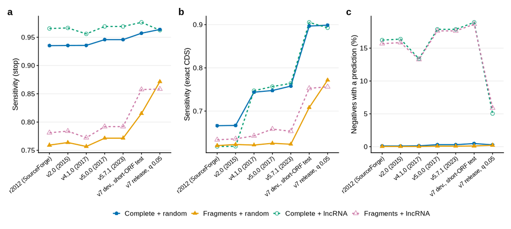

```r
SER_COL <- c("Complete + random" = "#0072B2", "Fragments + random" = "#E69F00",
             "Complete + lncRNA" = "#009E73", "Fragments + lncRNA" = "#CC79A7")
SER_LT <- c("Complete + random" = "solid", "Fragments + random" = "solid",
            "Complete + lncRNA" = "22", "Fragments + lncRNA" = "22")
SER_SH <- c("Complete + random" = 16, "Fragments + random" = 17,
            "Complete + lncRNA" = 1, "Fragments + lncRNA" = 2)
METRICS <- c(sens_stop = "Sensitivity (stop)", sens_exact = "Sensitivity (exact CDS)",
             neg_pct = "Negatives with a prediction (%)")

plot_df <- med %>%
  mutate(x = factor(RELEASES$axis[match(label, RELEASES$label)], levels = RELEASES$axis),
         series = factor(VARIANTS[as.character(variant)], levels = VARIANTS))

panel <- function(metric) {
  ggplot(plot_df, aes(x, .data[[metric]], colour = series, linetype = series, shape = series,
                      group = series)) +
    geom_line(linewidth = 0.5) +
    geom_point(size = 1.4) +
    scale_colour_manual(values = SER_COL, name = NULL) +
    scale_linetype_manual(values = SER_LT, name = NULL) +
    scale_shape_manual(values = SER_SH, name = NULL) +
    labs(x = NULL, y = METRICS[[metric]]) +
    theme(axis.text.x = element_text(size = 5.5, angle = 40, hjust = 1),
          panel.grid.major.y = element_line(linewidth = 0.2, colour = "grey90"))
}
p <- (panel("sens_stop") + panel("sens_exact") + panel("neg_pct")) +
  plot_layout(guides = "collect") + plot_annotation(tag_levels = "a") &
  theme(legend.position = "bottom")
save_fig(p, "figS3_history", FULL_W, 3)
p
```

**Plotted values (medians over organisms)**

```r
plot_df %>% arrange(series, x) %>%
  transmute(Input = series, Release = release, n_organisms = n_org, sens_stop = f3(sens_stop),
            sens_exact = f3(sens_exact), neg_pct = f1(neg_pct)) %>%
  kable()
```

| Input | Release | n_organisms | sens_stop | sens_exact | neg_pct |
| --- | --- | --- | --- | --- | --- |
| Complete + random | r2012-08-07 | 8 | 0.935 | 0.666 | 0.1 |
| Complete + random | v2.0 | 8 | 0.935 | 0.667 | 0.1 |
| Complete + random | v4.1.0 | 8 | 0.936 | 0.744 | 0.1 |
| Complete + random | v5.0.0 | 8 | 0.946 | 0.748 | 0.3 |
| Complete + random | v5.7.1 (= v6.0.0) | 8 | 0.946 | 0.758 | 0.3 |
| Complete + random | v7 development, fixed short-ORF test | 8 | 0.957 | 0.897 | 0.5 |
| Complete + random | v7 (release), q 0.05 | 8 | 0.964 | 0.899 | 0.3 |
| Fragments + random | r2012-08-07 | 8 | 0.759 | 0.620 | 0.0 |
| Fragments + random | v2.0 | 8 | 0.764 | 0.623 | 0.0 |
| Fragments + random | v4.1.0 | 8 | 0.757 | 0.621 | 0.0 |
| Fragments + random | v5.0.0 | 8 | 0.771 | 0.625 | 0.1 |
| Fragments + random | v5.7.1 (= v6.0.0) | 8 | 0.771 | 0.623 | 0.1 |
| Fragments + random | v7 development, fixed short-ORF test | 8 | 0.815 | 0.708 | 0.1 |
| Fragments + random | v7 (release), q 0.05 | 8 | 0.872 | 0.772 | 0.2 |
| Complete + lncRNA | r2012-08-07 | 2 | 0.965 | 0.618 | 16.2 |
| Complete + lncRNA | v2.0 | 2 | 0.966 | 0.618 | 16.4 |
| Complete + lncRNA | v4.1.0 | 2 | 0.956 | 0.747 | 13.4 |
| Complete + lncRNA | v5.0.0 | 2 | 0.969 | 0.757 | 17.9 |
| Complete + lncRNA | v5.7.1 (= v6.0.0) | 2 | 0.969 | 0.764 | 17.9 |
| Complete + lncRNA | v7 development, fixed short-ORF test | 2 | 0.976 | 0.905 | 18.9 |
| Complete + lncRNA | v7 (release), q 0.05 | 2 | 0.963 | 0.893 | 5.0 |
| Fragments + lncRNA | r2012-08-07 | 2 | 0.781 | 0.633 | 15.7 |
| Fragments + lncRNA | v2.0 | 2 | 0.784 | 0.636 | 15.8 |
| Fragments + lncRNA | v4.1.0 | 2 | 0.772 | 0.643 | 13.3 |
| Fragments + lncRNA | v5.0.0 | 2 | 0.792 | 0.658 | 17.6 |
| Fragments + lncRNA | v5.7.1 (= v6.0.0) | 2 | 0.792 | 0.653 | 17.6 |
| Fragments + lncRNA | v7 development, fixed short-ORF test | 2 | 0.857 | 0.753 | 18.6 |
| Fragments + lncRNA | v7 (release), q 0.05 | 2 | 0.858 | 0.756 | 5.9 |

**Per-organism values**

```r
scores %>%
  mutate(release = RELEASES$row[match(label, RELEASES$label)]) %>%
  transmute(org, variant, release, n_truth, tp_stop, tp_exact, n_pred, n_neg, neg_with_pred,
            sens_stop, sens_exact, neg_pct = round(100 * neg_rate, 2)) %>%
  arrange(variant, org, factor(release, levels = RELEASES$row)) %>%
  kable()
```

| org | variant | release | n_truth | tp_stop | tp_exact | n_pred | n_neg | neg_with_pred | sens_stop | sens_exact | neg_pct |
| --- | --- | --- | --- | --- | --- | --- | --- | --- | --- | --- | --- |
| human | complete.wLnc | r2012-08-07 | 19167 | 18546 | 10547 | 26333 | 33668 | 6006 | 0.9676006 | 0.5502687 | 17.84 |
| human | complete.wLnc | v2.0 | 19167 | 18567 | 10556 | 26589 | 33668 | 6013 | 0.9686962 | 0.5507382 | 17.86 |
| human | complete.wLnc | v4.1.0 | 19167 | 18470 | 13924 | 23410 | 33668 | 4891 | 0.9636354 | 0.7264569 | 14.53 |
| human | complete.wLnc | v5.0.0 | 19167 | 18629 | 14029 | 25272 | 33668 | 6598 | 0.9719309 | 0.7319351 | 19.60 |
| human | complete.wLnc | v5.7.1 (= v6.0.0) | 19167 | 18629 | 14317 | 26525 | 33668 | 6598 | 0.9719309 | 0.7469609 | 19.60 |
| human | complete.wLnc | v7 development, fixed short-ORF test | 19167 | 18775 | 17503 | 25766 | 33668 | 6943 | 0.9795482 | 0.9131841 | 20.62 |
| human | complete.wLnc | v7 (release), q 0.05 | 19167 | 18486 | 17241 | 20148 | 33668 | 1639 | 0.9644702 | 0.8995148 | 4.87 |
| mouse | complete.wLnc | r2012-08-07 | 21409 | 20622 | 14681 | 26314 | 31467 | 4598 | 0.9632398 | 0.6857396 | 14.61 |
| mouse | complete.wLnc | v2.0 | 21409 | 20642 | 14689 | 26741 | 31467 | 4686 | 0.9641739 | 0.6861133 | 14.89 |
| mouse | complete.wLnc | v4.1.0 | 21409 | 20301 | 16440 | 24296 | 31467 | 3854 | 0.9482461 | 0.7679013 | 12.25 |
| mouse | complete.wLnc | v5.0.0 | 21409 | 20684 | 16728 | 25863 | 31467 | 5075 | 0.9661357 | 0.7813536 | 16.13 |
| mouse | complete.wLnc | v5.7.1 (= v6.0.0) | 21409 | 20684 | 16728 | 26340 | 31467 | 5075 | 0.9661357 | 0.7813536 | 16.13 |
| mouse | complete.wLnc | v7 development, fixed short-ORF test | 21409 | 20834 | 19218 | 26368 | 31467 | 5423 | 0.9731421 | 0.8976599 | 17.23 |
| mouse | complete.wLnc | v7 (release), q 0.05 | 21409 | 20565 | 18973 | 22274 | 31467 | 1640 | 0.9605773 | 0.8862161 | 5.21 |
| athal | complete.wRand | r2012-08-07 | 26867 | 24863 | 17411 | 25147 | 26867 | 15 | 0.9254104 | 0.6480441 | 0.06 |
| athal | complete.wRand | v2.0 | 26867 | 24884 | 17425 | 25210 | 26867 | 16 | 0.9261920 | 0.6485652 | 0.06 |
| athal | complete.wRand | v4.1.0 | 26867 | 24825 | 19216 | 24933 | 26867 | 77 | 0.9239960 | 0.7152269 | 0.29 |
| athal | complete.wRand | v5.0.0 | 26867 | 25317 | 19560 | 25437 | 26867 | 81 | 0.9423084 | 0.7280307 | 0.30 |
| athal | complete.wRand | v5.7.1 (= v6.0.0) | 26867 | 25317 | 20279 | 25437 | 26867 | 81 | 0.9423084 | 0.7547921 | 0.30 |
| athal | complete.wRand | v7 development, fixed short-ORF test | 26867 | 25521 | 23509 | 25720 | 26867 | 146 | 0.9499014 | 0.8750140 | 0.54 |
| athal | complete.wRand | v7 (release), q 0.05 | 26867 | 25590 | 23557 | 25677 | 26867 | 39 | 0.9524696 | 0.8768005 | 0.15 |
| creinhardtii | complete.wRand | r2012-08-07 | 17621 | 16211 | 10244 | 17206 | 17621 | 658 | 0.9199818 | 0.5813518 | 3.73 |
| creinhardtii | complete.wRand | v2.0 | 17621 | 16222 | 10249 | 18082 | 17621 | 658 | 0.9206061 | 0.5816355 | 3.73 |
| creinhardtii | complete.wRand | v4.1.0 | 17621 | 16309 | 11358 | 16341 | 17621 | 1 | 0.9255434 | 0.6445718 | 0.01 |
| creinhardtii | complete.wRand | v5.0.0 | 17621 | 16364 | 11393 | 16456 | 17621 | 55 | 0.9286647 | 0.6465581 | 0.31 |
| creinhardtii | complete.wRand | v5.7.1 (= v6.0.0) | 17621 | 16364 | 11393 | 16457 | 17621 | 55 | 0.9286647 | 0.6465581 | 0.31 |
| creinhardtii | complete.wRand | v7 development, fixed short-ORF test | 17621 | 16580 | 12697 | 16689 | 17621 | 59 | 0.9409228 | 0.7205607 | 0.33 |
| creinhardtii | complete.wRand | v7 (release), q 0.05 | 17621 | 16806 | 12883 | 16943 | 17621 | 65 | 0.9537484 | 0.7311163 | 0.37 |
| dmel | complete.wRand | r2012-08-07 | 13884 | 12894 | 9992 | 12954 | 13884 | 7 | 0.9286949 | 0.7196773 | 0.05 |
| dmel | complete.wRand | v2.0 | 13884 | 12895 | 9993 | 13003 | 13884 | 7 | 0.9287669 | 0.7197494 | 0.05 |

[output cut: 110 more lines]

## Checks against the manuscript

The manuscript values are those in `supplement.tex` (Supplementary Note 1). Table cells are checked at the rounding of the table (3 decimals for sensitivity, 1 for percentages). The two v7 rows of the manuscript table are compared with the rows that replace them: the “fixed short-ORF test” row with the development run (`cliff_c200`) and the “v7 release, q 0.05” row with the release run (`pytd_v7`), which the table now holds.

```r
# manuscript tab:history (supplement.tex, Supplementary Note 1): stop / exact / % negatives
quoted <- tribble(
  ~label, ~variant, ~sens_stop, ~sens_exact, ~neg_pct,
  "r2012", "complete.wRand", 0.935, 0.666, 0.1, "r2012", "fragments.wRand", 0.759, 0.620, 0.0,
  "r2012", "complete.wLnc", 0.965, 0.618, 16.2, "r2012", "fragments.wLnc", 0.781, 0.633, 15.7,
  "v2.0", "complete.wRand", 0.935, 0.667, 0.1, "v2.0", "fragments.wRand", 0.764, 0.623, 0.0,
  "v2.0", "complete.wLnc", 0.966, 0.618, 16.4, "v2.0", "fragments.wLnc", 0.784, 0.636, 15.8,
  "v4.1.0", "complete.wRand", 0.936, 0.744, 0.1, "v4.1.0", "fragments.wRand", 0.757, 0.621, 0.0,
  "v4.1.0", "complete.wLnc", 0.956, 0.747, 13.4, "v4.1.0", "fragments.wLnc", 0.772, 0.643, 13.3,
  "v5.0.0", "complete.wRand", 0.946, 0.748, 0.3, "v5.0.0", "fragments.wRand", 0.771, 0.625, 0.1,
  "v5.0.0", "complete.wLnc", 0.969, 0.757, 17.9, "v5.0.0", "fragments.wLnc", 0.792, 0.658, 17.6,
  "v5.7.1", "complete.wRand", 0.946, 0.758, 0.3, "v5.7.1", "fragments.wRand", 0.771, 0.623, 0.1,
  "v5.7.1", "complete.wLnc", 0.969, 0.764, 17.9, "v5.7.1", "fragments.wLnc", 0.792, 0.653, 17.6,
  "cliff_c200", "complete.wRand", 0.957, 0.897, 0.5, "cliff_c200", "fragments.wRand", 0.815, 0.708, 0.1,
  "cliff_c200", "complete.wLnc", 0.976, 0.905, 18.9, "cliff_c200", "fragments.wLnc", 0.857, 0.753, 18.6,
  "pytd_v7", "complete.wRand", 0.964, 0.899, 0.3, "pytd_v7", "fragments.wRand", 0.872, 0.772, 0.2,
  "pytd_v7", "complete.wLnc", 0.963, 0.893, 5.0, "pytd_v7", "fragments.wLnc", 0.858, 0.756, 5.9
)
for (i in seq_len(nrow(quoted))) {
  q <- quoted[i, ]
  for (k in c("sens_stop", "sens_exact", "neg_pct")) {
    v <- m(q$label, q$variant, k)
    digits <- if (k == "neg_pct") 1 else 3
    check_text(sprintf("Table S11 %s %s %s", q$label, q$variant, k), round(v, digits), q[[k]])
  }
}
# paragraph after tab:history (supplement.tex)
check_text("random negatives, max median % (at most 0.5)", round(rand_max, 1), 0.5)
check_text("exact, complete+random, r2012", round(m("r2012", "complete.wRand", "sens_exact"), 3), 0.666)
check_text("exact, complete+random, v4.1.0", round(m("v4.1.0", "complete.wRand", "sens_exact"), 3), 0.744)
check_text("exact, complete+random, v7 start rule (dev. short-ORF test)",
           round(m("cliff_c200", "complete.wRand", "sens_exact"), 3), 0.897)
check_text("exact, complete+random, v7 start rule (release)",
           round(m("pytd_v7", "complete.wRand", "sens_exact"), 3), 0.899)
check_text("stop, fragments+random, 2012-v6.0.0 low (0.76)", round(min(frag_old), 2), 0.76)
check_text("stop, fragments+random, 2012-v6.0.0 high (0.77)", round(max(frag_old), 2), 0.77)
check_text("stop, fragments+random, v7 50-codon minimum (dev.)",
           round(m("cliff_c200", "fragments.wRand", "sens_stop"), 3), 0.815)
check_text("stop, fragments+random, v7 q-value test (release)",
           round(m("pytd_v7", "fragments.wRand", "sens_stop"), 3), 0.872)
check_text("lncRNA % before q-value test, low (13)", round(min(lnc_before_q)), 13)
check_text("lncRNA % before q-value test, high (19)", round(max(lnc_before_q)), 19)
check_text("lncRNA % with q-value test, low (5.0)", round(min(lnc_q), 1), 5.0)
check_text("lncRNA % with q-value test, high (5.9)", round(max(lnc_q), 1), 5.9)
check_report()
```

| claim | computed | manuscript | ok |
| --- | --- | --- | --- |
| Table S11 r2012 complete.wRand sens_stop | 0.935 | 0.935 | TRUE |
| Table S11 r2012 complete.wRand sens_exact | 0.666 | 0.666 | TRUE |
| Table S11 r2012 complete.wRand neg_pct | 0.1 | 0.1 | TRUE |
| Table S11 r2012 fragments.wRand sens_stop | 0.759 | 0.759 | TRUE |
| Table S11 r2012 fragments.wRand sens_exact | 0.62 | 0.62 | TRUE |
| Table S11 r2012 fragments.wRand neg_pct | 0 | 0 | TRUE |
| Table S11 r2012 complete.wLnc sens_stop | 0.965 | 0.965 | TRUE |
| Table S11 r2012 complete.wLnc sens_exact | 0.618 | 0.618 | TRUE |
| Table S11 r2012 complete.wLnc neg_pct | 16.2 | 16.2 | TRUE |
| Table S11 r2012 fragments.wLnc sens_stop | 0.781 | 0.781 | TRUE |
| Table S11 r2012 fragments.wLnc sens_exact | 0.633 | 0.633 | TRUE |
| Table S11 r2012 fragments.wLnc neg_pct | 15.7 | 15.7 | TRUE |
| Table S11 v2.0 complete.wRand sens_stop | 0.935 | 0.935 | TRUE |
| Table S11 v2.0 complete.wRand sens_exact | 0.667 | 0.667 | TRUE |
| Table S11 v2.0 complete.wRand neg_pct | 0.1 | 0.1 | TRUE |
| Table S11 v2.0 fragments.wRand sens_stop | 0.764 | 0.764 | TRUE |
| Table S11 v2.0 fragments.wRand sens_exact | 0.623 | 0.623 | TRUE |
| Table S11 v2.0 fragments.wRand neg_pct | 0 | 0 | TRUE |
| Table S11 v2.0 complete.wLnc sens_stop | 0.966 | 0.966 | TRUE |
| Table S11 v2.0 complete.wLnc sens_exact | 0.618 | 0.618 | TRUE |
| Table S11 v2.0 complete.wLnc neg_pct | 16.4 | 16.4 | TRUE |
| Table S11 v2.0 fragments.wLnc sens_stop | 0.784 | 0.784 | TRUE |
| Table S11 v2.0 fragments.wLnc sens_exact | 0.636 | 0.636 | TRUE |
| Table S11 v2.0 fragments.wLnc neg_pct | 15.8 | 15.8 | TRUE |
| Table S11 v4.1.0 complete.wRand sens_stop | 0.936 | 0.936 | TRUE |
| Table S11 v4.1.0 complete.wRand sens_exact | 0.744 | 0.744 | TRUE |
| Table S11 v4.1.0 complete.wRand neg_pct | 0.1 | 0.1 | TRUE |
| Table S11 v4.1.0 fragments.wRand sens_stop | 0.757 | 0.757 | TRUE |
| Table S11 v4.1.0 fragments.wRand sens_exact | 0.621 | 0.621 | TRUE |
| Table S11 v4.1.0 fragments.wRand neg_pct | 0 | 0 | TRUE |

[output cut: 67 more lines]